# Metagenome assembly analysis

# Combine all the data from MAG assembly

## Introduction

Here, we combine BLASTN and GTDB-tk results (on all contigs from MEGAHIT) with seqkit stats (on contigs and dereplicated bins).

## Load necessary libraries

```r
# install.packages(c("tidyverse", "data.table"))
library(tidyverse)
library(data.table)
# load(file="./output/rdafiles/mag-combine-all-data.Rdata")
```

## Load data.

```r
source(here::here("config/R/config.R"))# config file with global variables
source(here::here("config/R/themes.R"))# config file with themes
dir.create(file.path(mag.rdafiles),recursive = TRUE)
dir.create(file.path(mag.tables),recursive = TRUE)
```

```r
dir.create(file.path(mag.figures),recursive = TRUE)
```

## Read the seqkit stats.

Seqkit on MEGAHIT [VERY LARGE]

```r
seqkit.megahit.df<-data.table::fread(seqkit.megahit.fname,
                                     header = TRUE,
                              sep="\t")%>%
  as_tibble()%>%
  rename("sample_id" = "sample")
```

Seqkit on MetaBAT2

```r
seqkit.metabat2.df<-read.table(seqkit.metabat2.fname,header = TRUE,
                              sep="\t",comment.char = "")%>%
  as_tibble()%>%
  rename("sample_id" = "sample")
```

Seqkit on dRep

```r
seqkit.drep.df<-read.table(seqkit.drep.fname,header = TRUE,
                              sep="\t",comment.char = "")%>%
  as_tibble()%>%
  rename("sample_id" = "sample")
head(seqkit.megahit.df)%>%
  knitr::kable(format = "simple")%>%
  print()
```

```
##
##
## sample_id   contig_id      contig_length      GC      AT
## ----------  ------------  --------------  ------  ------
## 2D10        k141_0                   358    6.15   93.85
## 2D10        k141_164181              658   39.97   60.03
## 2D10        k141_97019               321   34.89   65.11
## 2D10        k141_37315               446   48.43   51.57
## 2D10        k141_111945              456   59.65   40.35
## 2D10        k141_1                   351   68.38   31.62
```

```r
head(seqkit.metabat2.df)%>%
  knitr::kable(format = "simple")%>%
  print()
```

```
##
##
## sample_id    bin_id  contig_id      contig_length      GC      AT
## ----------  -------  ------------  --------------  ------  ------
## 2D10            100  k141_14959              8429   61.92   38.08
## 2D10            100  k141_104486             5478   56.97   43.03
## 2D10            100  k141_37383              3741   59.48   40.52
## 2D10            100  k141_223951             3933   56.88   43.12
## 2D10            100  k141_231423            41915   62.00   38.00
## 2D10            100  k141_37478              5856   61.63   38.37
```

```r
head(seqkit.drep.df)%>%
  knitr::kable(format = "simple")%>%
  print()
```

```
##
##
## sample_id    bin_id  contig_id      contig_length      GC      AT
## ----------  -------  ------------  --------------  ------  ------
## 2D10            106  k141_142200            16466   57.49   42.51
## 2D10            106  k141_998               52537   61.47   38.53
## 2D10            106  k141_82854             25032   62.32   37.68
## 2D10            106  k141_120674            28507   62.41   37.59
## 2D10            106  k141_121046            10463   60.49   39.51
## 2D10            106  k141_90798             16624   62.53   37.47
```

3118148 contigs from MEGAHIT

```r
nrow(seqkit.megahit.df)
```

```
## [1] 3118148
```

156182 contigs from MetaBAT2

```r
nrow(seqkit.metabat2.df)
```

```
## [1] 156182
```

11456 contigs from dRep

```r
nrow(seqkit.drep.df)
```

```
## [1] 11456
```

```r
summary(seqkit.megahit.df)
```

```
##   sample_id          contig_id         contig_length          GC              AT
##  Length:3118148     Length:3118148     Min.   :   200   Min.   : 0.87   Min.   : 0.82
##  Class :character   Class :character   1st Qu.:   383   1st Qu.:41.45   1st Qu.:44.41
##  Mode  :character   Mode  :character   Median :   528   Median :48.75   Median :51.25
##                                        Mean   :  1370   Mean   :48.15   Mean   :51.85
##                                        3rd Qu.:   868   3rd Qu.:55.59   3rd Qu.:58.55
##                                        Max.   :821016   Max.   :99.18   Max.   :99.13
```

```r
summary(seqkit.metabat2.df)
```

```
##   sample_id             bin_id        contig_id         contig_length          GC              AT
##  Length:156182      Min.   :  1.00   Length:156182      Min.   :  2500   Min.   :14.45   Min.   :23.68
##  Class :character   1st Qu.: 35.00   Class :character   1st Qu.:  3479   1st Qu.:41.53   1st Qu.:42.29
##  Mode  :character   Median : 60.00   Mode  :character   Median :  5504   Median :49.40   Median :50.60
##                     Mean   : 62.16                      Mean   : 13314   Mean   :48.90   Mean   :51.10
##                     3rd Qu.: 86.00                      3rd Qu.: 12143   3rd Qu.:57.71   3rd Qu.:58.47
##                     Max.   :145.00                      Max.   :821016   Max.   :76.32   Max.   :85.55
```

```r
summary(seqkit.drep.df)
```

```
##   sample_id             bin_id        contig_id         contig_length          GC              AT
##  Length:11456       Min.   :  1.00   Length:11456       Min.   :  2500   Min.   :20.84   Min.   :26.32
##  Class :character   1st Qu.: 34.00   Class :character   1st Qu.:  6361   1st Qu.:40.69   1st Qu.:45.76
##  Mode  :character   Median : 63.00   Mode  :character   Median : 13319   Median :46.94   Median :53.06
##                     Mean   : 62.65                      Mean   : 26202   Mean   :47.47   Mean   :52.53
##                     3rd Qu.: 86.00                      3rd Qu.: 29251   3rd Qu.:54.24   3rd Qu.:59.31
##                     Max.   :142.00                      Max.   :674940   Max.   :73.68   Max.   :79.16
```

## Add drep clusters information.

We want to know which bins were assigned to which clusters, and which bins weren’t because they had low quality. We need it to get a more precise estimate of mapped reads. Read the data with all high-quality MAGs and their clusters

```r
drep.clusters<-read.csv(drep.clusters.fname)%>%
  as_tibble()%>%
  mutate(genome=gsub(paste0(metabat2.date_time,"_"),"",genome),
         genome=gsub(".fa","",genome))%>%
  separate_wider_delim(genome,delim = "_bin.",names = c("sample_id","bin_id"))%>%
  mutate(bin_id=as.integer(bin_id))
head(drep.clusters)%>%
  knitr::kable(format = "simple")%>%
  print()
```

```
##
##
## sample_id    bin_id  secondary_cluster    threshold  cluster_method   comparison_algorithm    primary_cluster
## ----------  -------  ------------------  ----------  ---------------  ---------------------  ----------------
## H3               42  1_1                       0.05  average          fastANI                               1
## Y66b             15  1_1                       0.05  average          fastANI                               1
## G18              52  2_0                       0.05  average          fastANI                               2
## H21             110  3_0                       0.05  average          fastANI                               3
## 2D14             98  4_1                       0.05  average          fastANI                               4
## G14              96  4_1                       0.05  average          fastANI                               4
```

Read the data with representative genomes and their clusters

```r
drep.winning_genomes<-read.csv(drep.winning_genomes.fname)%>%
  as_tibble()%>%
  mutate(genome=gsub(paste0(metabat2.date_time,"_"),"",genome),
         genome=gsub(".fa","",genome))%>%
  separate_wider_delim(genome,delim = "_bin.",names = c("sample_id","bin_id"))%>%
  mutate(bin_id=as.integer(bin_id))
head(drep.winning_genomes)%>%
  knitr::kable(format = "simple")%>%
  print()
```

```
##
##
## sample_id    bin_id  cluster        score
## ----------  -------  --------  ----------
## Y66b             15  1_1         94.02366
## G18              52  2_0         87.26024
## H21             110  3_0         97.50959
## 2D14             98  4_1        100.19536
## Y51b             13  5_1        101.36102
## H3              108  6_0         90.23830
```

Combine drep MAGs with other checkm2 MAGs

```r
drep.clusters.joined<-drep.winning_genomes%>%
  select(sample_id,bin_id,cluster)%>%
  rename("secondary_cluster" = "cluster",
         "drep_sample"= "sample_id",
         "drep_bin_id"= "bin_id")%>%
  full_join(drep.clusters[,c("sample_id","bin_id","secondary_cluster")],
            join_by("secondary_cluster"))%>%
  # Add a column that shows if a bin is representative or not.
  # Then, remove drep_sample and drep_bin_id because it's the same information
  mutate(is_representative_bin=ifelse(sample_id==drep_sample&bin_id==drep_bin_id,
                            TRUE,FALSE))%>%
  select(-drep_sample,-drep_bin_id)
head(drep.clusters.joined)%>%
  knitr::kable(format = "simple")%>%
  print()
```

```
##
##
## secondary_cluster   sample_id    bin_id  is_representative_bin
## ------------------  ----------  -------  ----------------------
## 1_1                 H3               42  FALSE
## 1_1                 Y66b             15  TRUE
## 2_0                 G18              52  TRUE
## 3_0                 H21             110  TRUE
## 4_1                 2D14             98  TRUE
## 4_1                 G14              96  FALSE
```

```r
rm(drep.clusters)
rm(drep.clusters.fname)
rm(drep.winning_genomes)
rm(drep.winning_genomes.fname)
```

### Join cluster information with seqkit stats.

```r
seqkit.drep.df<-seqkit.drep.df%>%
  left_join(drep.clusters.joined,by = join_by(sample_id, bin_id))

seqkit.metabat2.df <- seqkit.metabat2.df%>%
  left_join(drep.clusters.joined,by = join_by(sample_id, bin_id))%>%
  mutate(secondary_cluster = ifelse(is.na(secondary_cluster), "low_quality_mag",
                                    secondary_cluster),
         is_representative_bin = ifelse(is.na(is_representative_bin), "low_quality_mag",
                                        is_representative_bin)
         )

head(seqkit.drep.df)%>%
  knitr::kable(format = "simple")%>%
  print()
```

```
##
##
## sample_id    bin_id  contig_id      contig_length      GC      AT  secondary_cluster   is_representative_bin
## ----------  -------  ------------  --------------  ------  ------  ------------------  ----------------------
## 2D10            106  k141_142200            16466   57.49   42.51  47_1                TRUE
## 2D10            106  k141_998               52537   61.47   38.53  47_1                TRUE
## 2D10            106  k141_82854             25032   62.32   37.68  47_1                TRUE
## 2D10            106  k141_120674            28507   62.41   37.59  47_1                TRUE
## 2D10            106  k141_121046            10463   60.49   39.51  47_1                TRUE
## 2D10            106  k141_90798             16624   62.53   37.47  47_1                TRUE
```

```r
head(seqkit.metabat2.df)
```

```
## # A tibble: 6 × 8
##   sample_id bin_id contig_id   contig_length    GC    AT secondary_cluster is_representative_bin
##   <chr>      <int> <chr>               <int> <dbl> <dbl> <chr>             <chr>
## 1 2D10         100 k141_14959           8429  61.9  38.1 low_quality_mag   low_quality_mag
## 2 2D10         100 k141_104486          5478  57.0  43.0 low_quality_mag   low_quality_mag
## 3 2D10         100 k141_37383           3741  59.5  40.5 low_quality_mag   low_quality_mag
## 4 2D10         100 k141_223951          3933  56.9  43.1 low_quality_mag   low_quality_mag
## 5 2D10         100 k141_231423         41915  62    38   low_quality_mag   low_quality_mag
## 6 2D10         100 k141_37478           5856  61.6  38.4 low_quality_mag   low_quality_mag
```

```r
rm(drep.clusters.joined)
```

## Combine all seqkit statistics into one table.

First, we create a column with each contig + its bin + sample_id.

```r
seqkit.metabat2.df <- seqkit.metabat2.df%>%
  mutate(sample_contig=paste(sample_id,contig_id,sep = "_"),
         sample_bin_contig=paste(sample_id,bin_id,contig_id,sep = "_"))
seqkit.drep.df <- seqkit.drep.df%>%
  mutate(sample_contig=paste(sample_id,contig_id,sep = "_"),
         sample_bin_contig=paste(sample_id,bin_id,contig_id,sep = "_"))
seqkit.megahit.df <- seqkit.megahit.df%>%
  mutate(sample_contig=paste(sample_id,contig_id,sep = "_"))
head(seqkit.drep.df)%>%
  knitr::kable(format = "simple")%>%
  print()
```

```
##
##
## sample_id    bin_id  contig_id      contig_length      GC      AT  secondary_cluster   is_representative_bin   sample_contig      sample_bin_contig
## ----------  -------  ------------  --------------  ------  ------  ------------------  ----------------------  -----------------  ---------------------
## 2D10            106  k141_142200            16466   57.49   42.51  47_1                TRUE                    2D10_k141_142200   2D10_106_k141_142200
## 2D10            106  k141_998               52537   61.47   38.53  47_1                TRUE                    2D10_k141_998      2D10_106_k141_998
## 2D10            106  k141_82854             25032   62.32   37.68  47_1                TRUE                    2D10_k141_82854    2D10_106_k141_82854
## 2D10            106  k141_120674            28507   62.41   37.59  47_1                TRUE                    2D10_k141_120674   2D10_106_k141_120674
## 2D10            106  k141_121046            10463   60.49   39.51  47_1                TRUE                    2D10_k141_121046   2D10_106_k141_121046
## 2D10            106  k141_90798             16624   62.53   37.47  47_1                TRUE                    2D10_k141_90798    2D10_106_k141_90798
```

```r
head(seqkit.metabat2.df)%>%
  knitr::kable(format = "simple")%>%
  print()
```

```
##
##
## sample_id    bin_id  contig_id      contig_length      GC      AT  secondary_cluster   is_representative_bin   sample_contig      sample_bin_contig
## ----------  -------  ------------  --------------  ------  ------  ------------------  ----------------------  -----------------  ---------------------
## 2D10            100  k141_14959              8429   61.92   38.08  low_quality_mag     low_quality_mag         2D10_k141_14959    2D10_100_k141_14959
## 2D10            100  k141_104486             5478   56.97   43.03  low_quality_mag     low_quality_mag         2D10_k141_104486   2D10_100_k141_104486
## 2D10            100  k141_37383              3741   59.48   40.52  low_quality_mag     low_quality_mag         2D10_k141_37383    2D10_100_k141_37383
## 2D10            100  k141_223951             3933   56.88   43.12  low_quality_mag     low_quality_mag         2D10_k141_223951   2D10_100_k141_223951
## 2D10            100  k141_231423            41915   62.00   38.00  low_quality_mag     low_quality_mag         2D10_k141_231423   2D10_100_k141_231423
## 2D10            100  k141_37478              5856   61.63   38.37  low_quality_mag     low_quality_mag         2D10_k141_37478    2D10_100_k141_37478
```

```r
head(seqkit.megahit.df)%>%
  knitr::kable(format = "simple")%>%
  print()
```

```
##
##
## sample_id   contig_id      contig_length      GC      AT  sample_contig
## ----------  ------------  --------------  ------  ------  -----------------
## 2D10        k141_0                   358    6.15   93.85  2D10_k141_0
## 2D10        k141_164181              658   39.97   60.03  2D10_k141_164181
## 2D10        k141_97019               321   34.89   65.11  2D10_k141_97019
## 2D10        k141_37315               446   48.43   51.57  2D10_k141_37315
## 2D10        k141_111945              456   59.65   40.35  2D10_k141_111945
## 2D10        k141_1                   351   68.38   31.62  2D10_k141_1
```

```r
nrow(seqkit.drep.df)
```

```
## [1] 11456
```

```r
nrow(seqkit.metabat2.df)
```

```
## [1] 156182
```

```r
nrow(seqkit.megahit.df)
```

```
## [1] 3118148
```

Get the common IDs between datasets to know whether a contig was assembled (metabat2 or metabat2_drep) or not (megahit). If it’s metabat2, it is not representative. If it’s metabat2_drep, it is representative.

```r
megahit.metabat2.common.ids<-intersect(seqkit.megahit.df$sample_contig,
                                      seqkit.metabat2.df$sample_contig)
metabat2.drep.common.ids<-intersect(seqkit.metabat2.df$sample_bin_contig,
                                   seqkit.drep.df$sample_bin_contig)
megahit.drep.common.ids<-intersect(seqkit.megahit.df$sample_contig,
                                   seqkit.drep.df$sample_contig)
length(megahit.metabat2.common.ids)
```

```
## [1] 156182
```

```r
length(metabat2.drep.common.ids)
```

```
## [1] 11456
```

```r
length(megahit.drep.common.ids)
```

```
## [1] 11456
```

All contigs from drep are found in MetaBAT2 (no differences):

```r
length(setdiff(seqkit.drep.df$sample_bin_contig,
        seqkit.metabat2.df$sample_bin_contig))
```

```
## [1] 0
```

All contigs from MetaBAT2 are found in MEGAHIT (no differences):

```r
length(setdiff(seqkit.metabat2.df$sample_contig,
        seqkit.megahit.df$sample_contig))
```

```
## [1] 0
```

Finally combine the data:

```r
seqkit.all.df <- seqkit.megahit.df %>%
  full_join(subset(seqkit.metabat2.df,select = -c(AT,GC,sample_contig,
                                                      contig_length)),
            by = join_by(sample_id, contig_id))%>%
  relocate(sample_id,contig_id,bin_id)%>%
  # If bin_id, secondary_cluster, and is_representative_bin are NA, the contig was not assembled
  mutate(bin_id = ifelse(is.na(bin_id), "unassembled", bin_id),
         secondary_cluster = ifelse(is.na(secondary_cluster), "unassembled", secondary_cluster),
         is_representative_bin = ifelse(is.na(is_representative_bin), "unassembled", is_representative_bin))%>%
  select(-sample_contig,-sample_bin_contig)
head(seqkit.all.df)%>%
  knitr::kable(format = "simple")%>%
  print()
```

```
##
##
## sample_id   contig_id     bin_id         contig_length      GC      AT  secondary_cluster   is_representative_bin
## ----------  ------------  ------------  --------------  ------  ------  ------------------  ----------------------
## 2D10        k141_0        unassembled              358    6.15   93.85  unassembled         unassembled
## 2D10        k141_164181   unassembled              658   39.97   60.03  unassembled         unassembled
## 2D10        k141_97019    unassembled              321   34.89   65.11  unassembled         unassembled
## 2D10        k141_37315    unassembled              446   48.43   51.57  unassembled         unassembled
## 2D10        k141_111945   unassembled              456   59.65   40.35  unassembled         unassembled
## 2D10        k141_1        unassembled              351   68.38   31.62  unassembled         unassembled
```

```r
nrow(seqkit.all.df)
```

```
## [1] 3118148
```

```r
str(seqkit.all.df)
```

```
## tibble [3,118,148 × 8] (S3: tbl_df/tbl/data.frame)
##  $ sample_id            : chr [1:3118148] "2D10" "2D10" "2D10" "2D10" ...
##  $ contig_id            : chr [1:3118148] "k141_0" "k141_164181" "k141_97019" "k141_37315" ...
##  $ bin_id               : chr [1:3118148] "unassembled" "unassembled" "unassembled" "unassembled" ...
##  $ contig_length        : int [1:3118148] 358 658 321 446 456 351 1154 1561 232 385 ...
##  $ GC                   : num [1:3118148] 6.15 39.97 34.89 48.43 59.65 ...
##  $ AT                   : num [1:3118148] 93.8 60 65.1 51.6 40.4 ...
##  $ secondary_cluster    : chr [1:3118148] "unassembled" "unassembled" "unassembled" "unassembled" ...
##  $ is_representative_bin: chr [1:3118148] "unassembled" "unassembled" "unassembled" "unassembled" ...
##  - attr(*, ".internal.selfref")=<externalptr>
```

```r
summary(seqkit.all.df)
```

```
##   sample_id          contig_id            bin_id          contig_length          GC              AT        secondary_cluster  is_representative_bin
##  Length:3118148     Length:3118148     Length:3118148     Min.   :   200   Min.   : 0.87   Min.   : 0.82   Length:3118148     Length:3118148
##  Class :character   Class :character   Class :character   1st Qu.:   383   1st Qu.:41.45   1st Qu.:44.41   Class :character   Class :character
##  Mode  :character   Mode  :character   Mode  :character   Median :   528   Median :48.75   Median :51.25   Mode  :character   Mode  :character
##                                                           Mean   :  1370   Mean   :48.15   Mean   :51.85
##                                                           3rd Qu.:   868   3rd Qu.:55.59   3rd Qu.:58.55
##                                                           Max.   :821016   Max.   :99.18   Max.   :99.13
```

```r
rm(megahit.drep.common.ids)
rm(megahit.metabat2.common.ids)
rm(metabat2.drep.common.ids)
```

Barplot to count how many contigs were retained: most contigs weren’t assembled

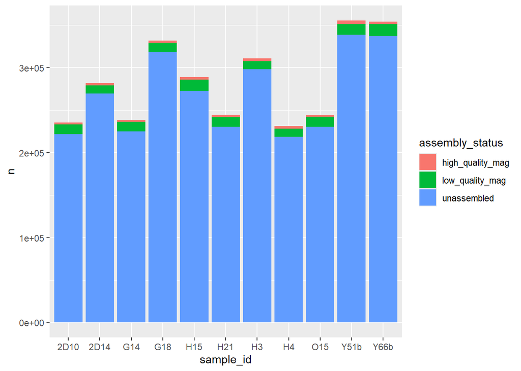

```r
seqkit.all.df%>%
  mutate(assembly_status = ifelse(! secondary_cluster %in% c("low_quality_mag",
                                                               "unassembled"),
                                    "high_quality_mag", secondary_cluster))%>%
  count(sample_id,assembly_status )%>%
  # pivot_wider(names_from = "assembly_status",
  #             values_from="n")%>%
  ggplot(aes(x=sample_id,fill=assembly_status,y=n))+
  geom_bar(stat="identity")
```

```r
rm(seqkit.drep.df)
rm(seqkit.megahit.df)
rm(seqkit.metabat2.df)
gc()
```

```
##            used  (Mb) gc trigger   (Mb)  max used   (Mb)
## Ncells  7818923 417.6   20872370 1114.8  20872370 1114.8
## Vcells 42936151 327.6  117702308  898.0 117147006  893.8
```

## Add taxonomy to the seqkit stats data.

### Add GTDB-tk taxonomy (for dereplicated bins).

```r
gtdbtk.taxonomy<-read.table(gtdbtk.taxonomy.fname,header = T,
                            sep="\t",comment.char = "")%>%
  as_tibble()%>%
  select(user_genome,classification) # remove unnecessary columns
head(gtdbtk.taxonomy)%>%
  knitr::kable(format = "simple")%>%
  print()
```

```
##
##
## user_genome                      classification
## -------------------------------  -----------------------------------------------------------------------------------------------------
## 20250612_13_37_47_2D10_bin.10    d__Bacteria;p__Bacteroidota;c__Bacteroidia;o__Bacteroidales;f__Muribaculaceae;g__Duncaniella;s__
## 20250612_13_37_47_2D10_bin.106   d__Bacteria;p__Bacteroidota;c__Bacteroidia;o__Bacteroidales;f__Muribaculaceae;g__CAG-873;s__
## 20250612_13_37_47_2D10_bin.11    d__Bacteria;p__Bacillota;c__Clostridia;o__Oscillospirales;f__Acutalibacteraceae;g__Acutalibacter;s__
## 20250612_13_37_47_2D10_bin.26    d__Bacteria;p__Bacteroidota;c__Bacteroidia;o__Bacteroidales;f__Bacteroidaceae;g__Prevotella;s__
## 20250612_13_37_47_2D10_bin.39    d__Bacteria;p__Bacteroidota;c__Bacteroidia;o__Bacteroidales;f__Bacteroidaceae;g__Prevotella;s__
## 20250612_13_37_47_2D10_bin.42    d__Bacteria;p__Bacillota;c__Clostridia;o__Christensenellales;f__Aristaeellaceae;g__;s__
```

```r
# 128 bins
nrow(gtdbtk.taxonomy)
```

```
## [1] 128
```

Tidy up GTDB-tk taxonomy: substitute s__ and g__ with unclassified Separate sample_bin column into separate columns

```r
gtdbtk.taxonomy<-gtdbtk.taxonomy %>%
  mutate(classification=gsub(";g__;s__",";unclassified;unclassified",
                             classification))%>%
  mutate(classification=gsub(";s__$",";unclassified",classification))%>%
  mutate(classification=gsub("d__|p__|c__|o__|f__|g__|s__","",classification)) %>%
  mutate(user_genome=gsub(paste0(metabat2.date_time,"_"),"",user_genome))%>%
  separate_wider_delim(user_genome,delim="_bin.",names=c("sample_id","bin_id"))%>%
  mutate(bin_id=as.integer(bin_id))
```

### Add BLAST taxonomy (for all contigs from MEGAHIT).

```r
blastn.taxonomy<-read.table(blastn.taxonomy.fname,header = F,
                            sep="\t",comment.char = "")%>%
  as_tibble()
head(blastn.taxonomy)%>%
  knitr::kable(format = "simple")%>%
  print()
```

```
##
##
## V1     V2            V3                          V4     V5     V6  V7
## -----  ------------  ---------------------  -------  -----  -----  ----------------------------------------------------------------------------------------------------------------------------
## 2D10   k141_105068   EF400498.1.1478         95.611   1162   1857  Bacteria;Bacillota;Clostridia;Peptostreptococcales-Tissierellales;Anaerovoracaceae;Family XIII UCG-001;uncultured bacterium
## 2D10   k141_10535    EU463109.1.1398         98.784   1398   2488  Bacteria;Bacteroidota;Bacteroidia;Bacteroidales;Prevotellaceae;Prevotellaceae UCG-001;uncultured bacterium
## 2D10   k141_106439   KY635417.1.1502         91.935    992   1382  Bacteria;Thermodesulfobacteriota;Desulfovibrionia;Desulfovibrionales;Desulfovibrionaceae;Bilophila;uncultured bacterium
## 2D10   k141_107540   CP015406.84360.85899    95.040    504    791  Bacteria;Bacillota;Clostridia;Oscillospirales;Oscillospiraceae;Flavonifractor;Flavonifractor plautii
## 2D10   k141_108239   JN162690.1.1347         95.085    529    832  Bacteria;Actinomycetota;Coriobacteriia;Coriobacteriales;Atopobiaceae;Incertae Sedis;uncultured bacterium
## 2D10   k141_108435   EU622679.1.1499         98.679    984   1746  Bacteria;Bacillota;Clostridia;Lachnospirales;Lachnospiraceae;[Eubacterium] ventriosum group;uncultured bacterium
```

```r
# 1899 contigs
nrow(blastn.taxonomy)
```

```
## [1] 1899
```

```r
colnames(blastn.taxonomy)<-c("sample_id","contig_id","silva_ref_id","perc_identity",
                             "alignment_length","bitscore","classification")
```

### Join stats with taxonomy.

```r
###NOT NEEDED?
# seqkit.with_taxonomy<-seqkit.all.df%>%
#   full_join(gtdbtk.taxonomy,
#             by = join_by(sample_id, bin_id))%>%
#   full_join(blastn.taxonomy[,c("sample_id","contig_id","classification")],
#             by = join_by(sample_id, contig_id))%>%
#   rename("gtdbtk_result"="classification.x",
#          "blastn_result"="classification.y")%>%
#   ### 6.4 Add column to show if a contig was classified, and which pipeline classified it ####
#   mutate(tax.classification.type=ifelse(!is.na(gtdbtk_result)&!is.na(blastn_result),
#                         "gtdbtk_and_blastn","unclassified"),
#          tax.classification.type=ifelse(!is.na(gtdbtk_result)&is.na(blastn_result),
#                         "gtdbtk_only",tax.classification.type),
#          tax.classification.type=ifelse(is.na(gtdbtk_result)&!is.na(blastn_result),
#                         "blastn_only",tax.classification.type))
# nrow(seqkit.with_taxonomy)
# head(seqkit.with_taxonomy)
# str(seqkit.with_taxonomy)
# summary(seqkit.with_taxonomy)
# rm(seqkit.all.df)
```

## Add bin and contig coverages from CoverM.

### CoverM data from dRep.

```r
coverm.drep.df<-read.table(coverm.drep.fname,header = T,
                           sep = "\t")%>%
  as_tibble()%>%
  mutate(genome=gsub(paste0(metabat2.date_time,"_"),"",genome))
head(coverm.drep.df)%>%
  knitr::kable(format = "simple")%>%
  print()
```

```
##
##
## genome           relative_abundance        mean   trimmed_mean   covered_fraction   covered_bases    variance    length   read_count   reads_per_base        rpkm         tpm
## --------------  -------------------  ----------  -------------  -----------------  --------------  ----------  --------  -----------  ---------------  ----------  ----------
## unmapped_2D10            87.1793300          NA             NA                 NA              NA          NA        NA           NA               NA          NA          NA
## 2D10_bin.106              1.8713269    82.58569       78.43517          0.9999754         2110166   1539.1360   2110218      1225708        0.5808443    60.88153   147317.61
## 2D10_bin.10               0.9019371    39.80443       36.12676          0.9999700         2401556    938.5855   2401628       685978        0.2856304    29.93852    72443.48
## 2D10_bin.11               0.4851722    21.41170       20.91922          1.0000000         1193490    150.0317   1193490       172989        0.1449438    15.19237    36761.61
## 2D10_bin.26               1.3692596    60.42838       55.94852          0.9999195         3378337   1459.7344   3378609      1469758        0.4350187    45.59673   110332.31
## 2D10_bin.39               3.3015501   145.70453      142.67023          0.9998766         2915798   2382.5125   2916158      2906398        0.9966531   104.46478   252777.78
```

```r
nrow(coverm.drep.df)
```

```
## [1] 139
```

### CoverM data from MetaBAT2.

```r
coverm.metabat2.df<-read.table(coverm.metabat2.fname,header = T,
                               sep = "\t")%>%
  as_tibble()%>%
  mutate(genome=gsub(paste0(metabat2.date_time,"_"),"",genome))
head(coverm.metabat2.df)%>%
  knitr::kable(format = "simple")%>%
  print()
```

```
##
##
## genome           relative_abundance        mean   trimmed_mean   covered_fraction   covered_bases    variance    length   read_count   reads_per_base        rpkm        tpm
## --------------  -------------------  ----------  -------------  -----------------  --------------  ----------  --------  -----------  ---------------  ----------  ---------
## unmapped_2D10            20.8537700          NA             NA                 NA              NA          NA        NA           NA               NA          NA         NA
## 2D10_bin.100              0.4797199   31.469807      30.401953          0.9998561         2251352   388.04904   2251676       481084        0.2136560   3.6276174   6098.809
## 2D10_bin.101              0.4770218   31.292807      31.020714          1.0000000          811662    74.06812    811662       169735        0.2091203   3.5506072   5969.336
## 2D10_bin.102              0.1502874    9.858910       9.658344          0.9998679         1498842    19.62712   1499040        99069        0.0660883   1.1220986   1886.491
## 2D10_bin.103              0.0999692    6.558015       6.316923          0.9998813          606527    13.67829    606599        26712        0.0440357   0.7476721   1256.998
## 2D10_bin.104              0.1075584    7.055874       6.653600          0.9999239          525867    32.74173    525907        25613        0.0487025   0.8269095   1390.213
```

```r
nrow(coverm.metabat2.df)
```

```
## [1] 1352
```

### CoverM data from MEGAHIT (use data.table package).

```r
coverm.megahit.df<-data.table::fread(coverm.megahit.fname,header = T,
                                  sep = "\t")%>%
  as_tibble()%>%
  rename(sample_contig=contig)%>%
  separate_wider_delim(sample_contig,delim = "_",
                       names = c("sample_id","contig_id"),
                       too_many="merge" )
head(coverm.megahit.df)%>%
  knitr::kable(format = "simple")%>%
  print()
```

```
##
##
## sample_id   contig_id             mean   trimmed_mean   covered_fraction   covered_bases       variance   length   read_count   reads_per_base          rpkm            tpm
## ----------  ------------  ------------  -------------  -----------------  --------------  -------------  -------  -----------  ---------------  ------------  -------------
## 2D10        k141_0         2150.101000    2156.069000                  1             358   2.036667e+06      358         5671       15.8407820   220.8570000   1222.1907000
## 2D10        k141_164181       3.305118       3.320961                  1             658   1.506325e+00      658           15        0.0227964     0.3178337      1.7588462
## 2D10        k141_97019        1.736842       1.780645                  1             321   1.950464e-01      321            4        0.0124611     0.1737359      0.9614291
## 2D10        k141_37315        4.581081       4.574627                  1             446   3.044251e+00      446           13        0.0291480     0.4063900      2.2489035
## 2D10        k141_111945       3.866013       3.851449                  1             456   1.742644e+00      456           12        0.0263158     0.3669027      2.0303862
## 2D10        k141_1            6.487562       6.607735                  1             351   5.091095e+00      351           12        0.0341880     0.4766600      2.6377685
```

```r
nrow(coverm.megahit.df)
```

```
## [1] 3118148
```

How much relative abundance is classified in drep bins:

```r
coverm.drep.df%>%
  mutate(sample_id=ifelse(grepl("unmapped",genome),
                       gsub("unmapped_","",genome),
                       gsub("_bin.[0-9]*","",genome)))%>%
  filter(!grepl("unmapped",genome))%>%
  group_by(sample_id)%>%
  summarise(sum_relative_ab=sum(relative_abundance))
```

```
## # A tibble: 11 × 2
##    sample_id sum_relative_ab
##    <chr>               <dbl>
##  1 2D10                12.8
##  2 2D14                 6.24
##  3 G14                  3.82
##  4 G18                 20.3
##  5 H15                  8.84
##  6 H21                  7.36
##  7 H3                   4.26
##  8 H4                  11.8
##  9 O15                  5.88
## 10 Y51b                 5.53
## 11 Y66b                 3.79
```

How much relative abundance is classified in MetaBAT2 bins:

```r
coverm.metabat2.df%>%
  mutate(sample_id=ifelse(grepl("unmapped",genome),
                       gsub("unmapped_","",genome),
                       gsub("_bin.[0-9]*","",genome)))%>%
  filter(!grepl("unmapped",genome))%>%
  group_by(sample_id)%>%
  summarise(sum_relative_ab=sum(relative_abundance))
```

```
## # A tibble: 11 × 2
##    sample_id sum_relative_ab
##    <chr>               <dbl>
##  1 2D10                 79.1
##  2 2D14                 80.0
##  3 G14                  80.2
##  4 G18                  78.7
##  5 H15                  77.0
##  6 H21                  80.3
##  7 H3                   77.7
##  8 H4                   79.4
##  9 O15                  79.4
## 10 Y51b                 75.1
## 11 Y66b                 74.1
```

How much relative abundance is classified in MetaBAT2 bins that belonged to drep clusters:

```r
# seqkit.with_taxonomy%>%
seqkit.all.df%>%
  filter(!secondary_cluster %in% c("unassembled", "low_quality_mag"))%>%
  mutate(genome=paste(sample_id,bin_id,sep="_bin."))%>%
  distinct(sample_id,bin_id,genome,secondary_cluster)%>%
  left_join(coverm.metabat2.df,by=join_by("genome"))%>%
  group_by(sample_id)%>%
  summarise(sum_relative_ab=sum(relative_abundance))
```

```
## # A tibble: 11 × 2
##    sample_id sum_relative_ab
##    <chr>               <dbl>
##  1 2D10                21.7
##  2 2D14                15.0
##  3 G14                  9.75
##  4 G18                 18.5
##  5 H15                 23.4
##  6 H21                 15.8
##  7 H3                  18.7
##  8 H4                  24.6
##  9 O15                  8.53
## 10 Y51b                12.3
## 11 Y66b                17.0
```

## Join relative abundances with taxonomy.

### GTDB-tk + dRep

```r
gtdbtk.coverm.drep <- seqkit.all.df%>% # seqkit.with_taxonomy%>%
  filter(!secondary_cluster %in% c("unassembled", "low_quality_mag"))%>%
  select(sample_id,bin_id,secondary_cluster)%>%
  distinct()%>%
  mutate(bin_id = as.integer(bin_id))%>% # conver bin_id into integer because we will join it with the gtdbtk data
  right_join(gtdbtk.taxonomy)%>%
  mutate(genome=paste(sample_id,bin_id,sep="_bin."))%>%
  left_join(coverm.drep.df[,c("genome","relative_abundance")],
            by=join_by("genome"))%>% # here, we add the relative abundances
  select(-genome)
head(gtdbtk.coverm.drep)%>%
  knitr::kable(format = "simple")%>%
  print()
```

```
##
##
## sample_id    bin_id  secondary_cluster   classification                                                                                   relative_abundance
## ----------  -------  ------------------  ----------------------------------------------------------------------------------------------  -------------------
## 2D10             42  69_0                Bacteria;Bacillota;Clostridia;Christensenellales;Aristaeellaceae;unclassified;unclassified                0.3339523
## 2D10             26  60_0                Bacteria;Bacteroidota;Bacteroidia;Bacteroidales;Bacteroidaceae;Prevotella;unclassified                    1.3692596
## 2D10             62  28_1                Bacteria;Bacteroidota;Bacteroidia;Bacteroidales;UBA932;Cryptobacteroides;unclassified                     0.5458188
## 2D10             39  54_1                Bacteria;Bacteroidota;Bacteroidia;Bacteroidales;Bacteroidaceae;Prevotella;unclassified                    3.3015501
## 2D10             71  92_0                Bacteria;Bacillota;Clostridia;Oscillospirales;Acutalibacteraceae;Ruminococcoides;unclassified             0.2615794
## 2D10             76  105_0               Bacteria;Spirochaetota;Spirochaetia;Treponematales;Treponemataceae;Treponema_D;unclassified               0.4004118
```

### GTDB-tk + MetaBAT2

```r
gtdbtk.coverm.metabat2 <- seqkit.all.df%>% # seqkit.with_taxonomy%>%
  filter(!secondary_cluster %in% c("unassembled", "low_quality_mag"))%>%
  distinct(sample_id,bin_id,secondary_cluster)%>%
  mutate(bin_id = as.integer(bin_id))%>%
  # full_join(gtdbtk.taxonomy,by = join_by(sample_id, bin_id)) %>%
  full_join(gtdbtk.coverm.drep[,c("secondary_cluster","classification")],
            by = join_by(secondary_cluster)) %>% # add the previous dataset because it has secondary_cluster info
  group_by(secondary_cluster) %>%
  mutate(classification = classification[!is.na(classification)][1L])%>% # remove NAs
  ungroup%>%
  mutate(genome=paste(sample_id,bin_id,sep="_bin."))%>%
  left_join(coverm.metabat2.df[,c("genome","relative_abundance")],
            by=join_by("genome"))%>% # add relative abundances
  select(-genome)
head(gtdbtk.coverm.metabat2) %>%
  knitr::kable(format = "simple")%>%
  print()
```

```
##
##
## sample_id    bin_id  secondary_cluster   classification                                                                                     relative_abundance
## ----------  -------  ------------------  ------------------------------------------------------------------------------------------------  -------------------
## 2D10             52  57_1                Bacteria;Bacteroidota;Bacteroidia;Bacteroidales;Marinilabiliaceae;W3P20-009;unclassified                    0.1983270
## 2D10             42  69_0                Bacteria;Bacillota;Clostridia;Christensenellales;Aristaeellaceae;unclassified;unclassified                  0.2103324
## 2D10             89  108_1               Bacteria;Fibrobacterota;Fibrobacteria;Fibrobacterales;Fibrobacteraceae;Fibrobacter;unclassified             4.8582480
## 2D10              3  88_1                Bacteria;Bacillota;Clostridia;Lachnospirales;Lachnospiraceae;Anaerostipes;Anaerostipes caccae               0.1971572
## 2D10             45  59_1                Bacteria;Bacteroidota;Bacteroidia;Bacteroidales;Bacteroidaceae;Prevotella;unclassified                      0.5177506
## 2D10             32  45_1                Bacteria;Bacteroidota;Bacteroidia;Bacteroidales;Muribaculaceae;CAG-873;unclassified                         0.7969444
```

### BLASTN + MEGAHIT

```r
blastn.coverm.megahit <- coverm.megahit.df%>%
  select(sample_id, contig_id,tpm)%>%
  inner_join(blastn.taxonomy,by = join_by(sample_id, contig_id))
head(blastn.coverm.megahit)%>%
  knitr::kable(format = "simple")%>%
  print()
```

```
##
##
## sample_id   contig_id            tpm  silva_ref_id             perc_identity   alignment_length   bitscore  classification
## ----------  ------------  ----------  ----------------------  --------------  -----------------  ---------  ---------------------------------------------------------------------------------------------------------------
## 2D10        k141_82202      3.633326  KM098109.1.1519                 94.706                510        791  Bacteria;Bacillota;Clostridia;Oscillospirales;Ruminococcaceae;Ruthenibacterium;Ruthenibacterium lactatiformans
## 2D10        k141_119595    18.049273  EF404262.1.1485                 99.811                528        970  Bacteria;Bacillota;Clostridia;Oscillospirales;Ruminococcaceae;Acutalibacter;uncultured bacterium
## 2D10        k141_231553    13.820761  EU777025.1.1401                 99.453                548        996  Bacteria;Bacteroidota;Bacteroidia;Bacteroidales;Prevotellaceae;Xylanibacter;uncultured bacterium
## 2D10        k141_119623    38.320625  NFZD01007643.88.1579            94.703               1246       1930  Bacteria;Bacillota;Bacilli;Erysipelotrichales;Erysipelatoclostridiaceae;Asteroleplasma;gut metagenome
## 2D10        k141_127099     1.975347  AM982589.1.1482                 93.514                663        985  Bacteria;Bacillota;Bacilli;Erysipelotrichales;Erysipelatoclostridiaceae;UCG-004;uncultured bacterium
## 2D10        k141_97310      5.611254  FBXW01000008.267.1775           99.545                660       1203  Bacteria;Bacillota;Clostridia;Oscillospirales;Oscillospiraceae;Incertae Sedis;Intestinimonas sp. GM5
```

```r
# Remove CoverM data because it's already join with taxonomy
rm(coverm.drep.df)
rm(coverm.metabat2.df)
rm(coverm.megahit.df)
rm(blastn.taxonomy)
```

Save data

```r
if (!file.exists(seqkit.all.df.fname.rds) & !file.exists(seqkit.all.df.fname.tsv)){
  saveRDS(seqkit.all.df, file = seqkit.all.df.fname.rds)
  data.table::fwrite(seqkit.all.df,
              file = seqkit.all.df.fname.tsv,
              col.names = TRUE,
              row.names = FALSE,
              quote = FALSE,
              sep = '\t',
              na =NA)

}

if (!file.exists(gtdbtk.coverm.drep.fname.rds) & !file.exists(gtdbtk.coverm.drep.fname.tsv)){
  saveRDS(gtdbtk.coverm.drep,file = gtdbtk.coverm.drep.fname.rds)
  write.table(gtdbtk.coverm.drep,
              file = gtdbtk.coverm.drep.fname.tsv,
              col.names = TRUE,
              row.names = FALSE,
              quote = FALSE,
              sep = '\t')

}
if (!file.exists(gtdbtk.coverm.metabat2.fname.rds) & !file.exists(gtdbtk.coverm.metabat2.fname.tsv)){
  saveRDS(gtdbtk.coverm.metabat2,file = gtdbtk.coverm.metabat2.fname.rds)
  write.table(gtdbtk.coverm.metabat2,
              file = gtdbtk.coverm.metabat2.fname.tsv,
              col.names = TRUE,
              row.names = FALSE,
              quote = FALSE,
              sep = '\t')

}
if (!file.exists(blastn.coverm.megahit.fname.rds) & !file.exists(blastn.coverm.megahit.fname.tsv)){
  saveRDS(blastn.coverm.megahit,file = blastn.coverm.megahit.fname.rds)
  write.table(blastn.coverm.megahit,
              file = blastn.coverm.megahit.fname.tsv,
              col.names = TRUE,
              row.names = FALSE,
              quote = FALSE,
              sep = '\t')

}
```

```r
rm(list = ls(all=TRUE))
gc()
```

```
##            used  (Mb) gc trigger   (Mb)  max used   (Mb)
## Ncells  7436357 397.2   20872370 1114.8  20872370 1114.8
## Vcells 18779406 143.3  113267155  864.2 141583943 1080.2
```